# **CMU 16825 Learning for 3D Vision – Assignment 1 Submission**

## **Patrick Chen** *(Andrew ID: bochunc)*

### **Task 1: Camera Effects & Motion**

🔹**360-degree Renders**  
🔹**Re-creating the Dolly Zoom**

### **Task 2: 3D Shape Construction**

🔹**Constructing a Tetrahedron**  
🔹**Constructing a Cube**

### **Task 3: Texturing & Materials**

🔹**Re-texturing a Mesh**

### **Task 4: Camera Transformations**

🔹**Camera Transformations**

### **Task 5: Rendering Generic 3D Representations**

🔹**Rendering Point Clouds from RGB-D Images**  
🔹**Parametric Functions**  
🔹**Implicit Surfaces**

### **Task 6: Do Something Fun**

🔹**Creative Use of the Tools**

### **Task 7: Sampling Points on Meshes**

🔹**Render PointCloud from Mesh**

## Task 1.1: 360-degree Renders (5 points)

Here is a rendered 360-degree gif video of the provided cow mesh:

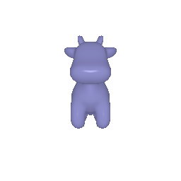

## Task 1.2: Re-creating the Dolly Zoom (10 points)

Here is a rendered dolly zoom effect gif of the provided cow mesh:

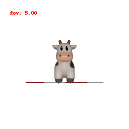

## Task 2.1: Constructing a Tetrahedron (5 points)

Here is the 360-degree gif animation of my tetrahedron, including 4 vertices and 4 (triangle) faces:

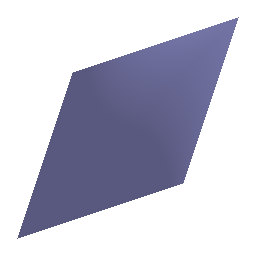

## Task 2.2: Constructing a Cube (5 points)

Here is the 360-degree gif animation of my cube, including 8 vertices and 12 (triangle) faces:

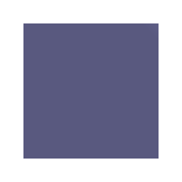

## Task 3: Re-texturing a mesh (10 points)

Here is the 360-degree re-texturing gif of the cow, with color1 = [0, 0, 1] and color2 = [1, 0, 0]

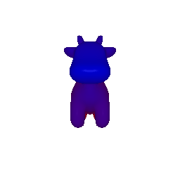

## Task 4: Camera Transformations (10 points)

In the first transform:

$$ T_{\text{relative}} = \begin{bmatrix} 0 & 0 & 0 \end{bmatrix} $$

$$ R_{\text{relative}} = \begin{bmatrix} 0 & 1 & 0 \\ -1 & 0 & 0 \\ 0 & 0 & 1 \end{bmatrix} $$

rendered result:

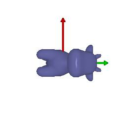

In the second transform:

$$ T_{\text{relative}} = \begin{bmatrix} 0 & 0 & 2 \end{bmatrix} $$

rendered result:

[figure not shown]

In the third transform:

$$ T_{\text{relative}} = \begin{bmatrix} 0.35 & -0.5 & 0 \end{bmatrix} $$

$$ R_{\text{relative}} = \begin{bmatrix} \cos\left(\frac{\pi}{180} \times \theta\right) & 0 & \sin\left(\frac{\pi}{180} \times \theta\right) \\ 0 & 1 & 0 \\ -\sin\left(\frac{\pi}{180} \times \theta\right) & 0 & \cos\left(\frac{\pi}{180} \times \theta\right) \end{bmatrix}^T \quad \text{with } \theta = -5^\circ $$

rendered result:

[figure not shown]

In the fourth transform:

In order to place the final camera position in [0, 0, -3], I set the following T_relative, with corresponding R_relative for the rotation on y-axis. $$ T_{\text{relative}} = \begin{bmatrix} -3 & 0 & 3\end{bmatrix} $$

$$ R_{\text{relative}} = \begin{bmatrix} \cos\left(\frac{\pi}{180} \times \theta\right) & 0 & \sin\left(\frac{\pi}{180} \times \theta\right) \\ 0 & 1 & 0 \\ -\sin\left(\frac{\pi}{180} \times \theta\right) & 0 & \cos\left(\frac{\pi}{180} \times \theta\right) \end{bmatrix}^T \quad \text{with } \theta = -90^\circ $$

rendered result:

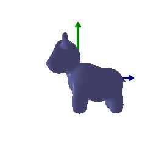

## Task 5: Rendering Generic 3D Representations

### 5.1 Rendering Point Clouds from RGB-D Images (10 points)

The following shows the three rendered point clouds from 2 images.

1. The point cloud corresponding to the first image (Below Left GIF, First Image)
2. The point cloud corresponding to the second image (Below Middle GIF, Second Image)
3. The point cloud formed by the union of the first 2 point clouds. (Below Right GIF, Merged)

First Image

Second Image

Merged

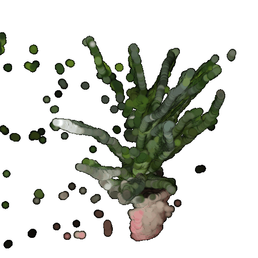

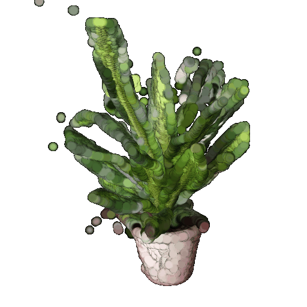

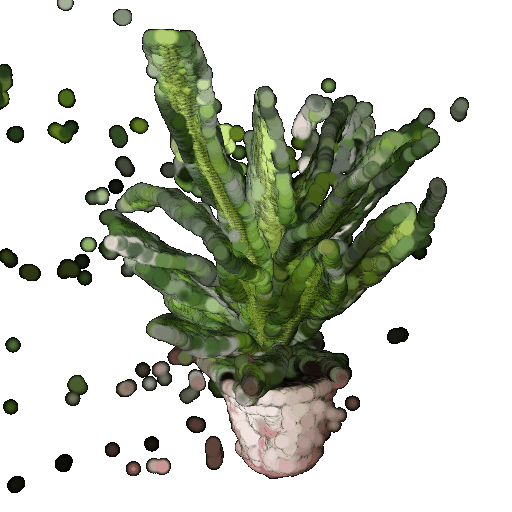

### 5.2 Parametric Functions (10 + 5 points)

The following shows the torus point cloud and customized one sheet hyperboloid (new object):

Torus Point Cloud

One Sheet Hyperboloid Point Cloud

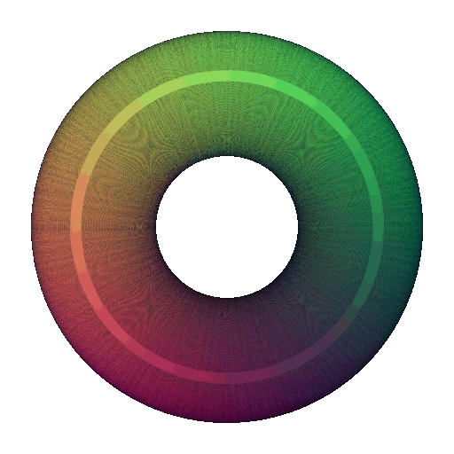

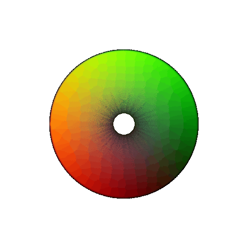

### 5.3 Implicit Surfaces (15 + 5 points)

The following shows the torus mesh rendering and customized two sheet hyperboloid mesh rendering (new object):

Torus Mesh

Two Sheet Hyperboloid Mesh

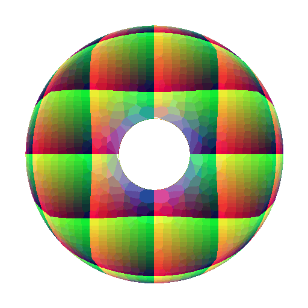

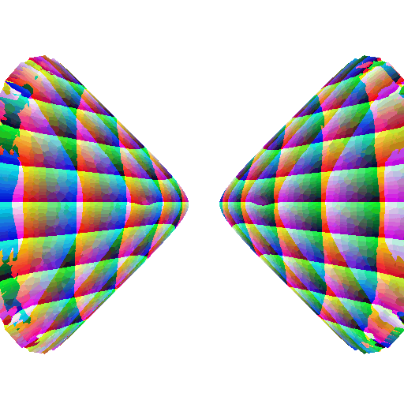

#### Discussion Tradeoff Between Rendering Mesh VS Point Cloud

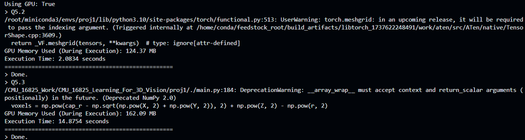

As we can see from the above standard output, the Point Cloud Rendering has much smaller execution time (2.083 seconds vs 14.875 seconds) and slightly smaller GPU memory usage (124.37 MB vs 162.09 MB) compared with Mesh Rendering under same number of samples and voxel size (600). Let's analyze as following:

1. Point Cloud Rendering is faster than Mesh Rendering:

A point cloud renderer simply plots points onto the screen, while a mesh renderer must perform triangle rasterization, normal computation, and fragment shading, which is computationally much more expensive. Besides, the mesh renderer needs to handle vertex connectivity and fill pixels inside triangles. On the other hand, the point cloud renderer does not need to handle triangle interpolation or normals calculation.

2. Point Cloud Rendering uses less GPU memory than Mesh Rendering:

A point cloud renderer only needs to store XYZ positions and colors, while a mesh renderer has to store triangle vertices, faces, textures, and normal vectors. In addition, the mesh renderer needs to calculate shading, lighting, and interpolation accross triangles, requiring additional GPU memory buffers.

3. Rendering Quality:

The rendering result of a point cloud renderer shows a smoother appearance, but it lacks surface connectivity, which could lead to gaps when the density (number of samples) is low. On the other hand, the mesh rendering provides well-defined structure with sharper edges and better shading, but it could become blocky if the resolution is low.

4. Ease of Use:

Point clouds are easier to generate, but they are harder to render and use in simulations due to the lack of surface continuity. On the other hand, meshes are more complex to generate because they require algorithms like marching cube to grab the zero level-set point of an implicit function, but they are easier to be used in physics simulations and graphics pipelines as they provide continuous, structured surfaces with well-defined connectivity between vertices.

### 6 Do Something Fun (10 points)

Here is the rendering result that I tried something fun: A cow is being abducted by an UFO.

The tools I used including:

1. A new model from Free3D, which is an UFO, and I use texture tool: pytorch3d.renderer.Textures to render the mesh with textures.
2. Render the cow provided in data folder with its texture using texture tool: pytorch3d.renderer.Textures.
3. Apply rotation matrix on y-axis to give rotation effect on both UFO and cow rendered objects.
4. Apply translation changing along y-axis on the vertices of the cow object to create a visual effect that the cow is being abducted by an UFO.
5. Use tool: pytorch3d.structures.join_meshes_as_scene to join the mesh of cow and UFO.
6. Use tool: pytorch3d.renderer.look_at_view_transform to get the world to camera transformation.
7. Use tool: pytorch3d.renderer.FoVPerspectiveCameras to get the camera object for rendering.
8. Use tool: starter.utils.get_mesh_renderer to render the frames of GIF.
9. Use tool: imageio.mimsave to save the rendered results in GIF file.

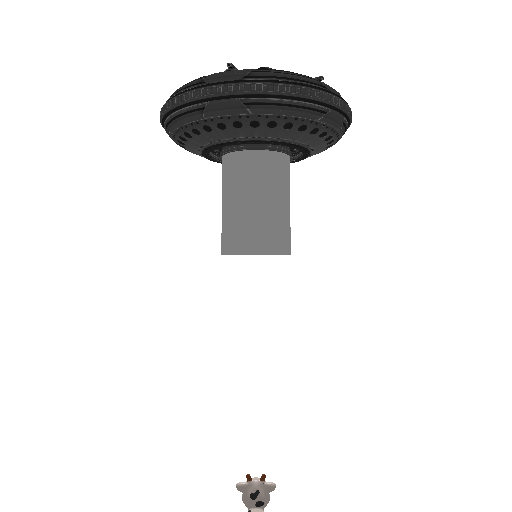

### (Extra Credit) 7. Sampling Points on Meshes (10 points)

The following results are the rendering pointclouds from the original cow mesh.

Original Cow Mesh

PointCloud w/ 10 points

PointCloud w/ 100 points

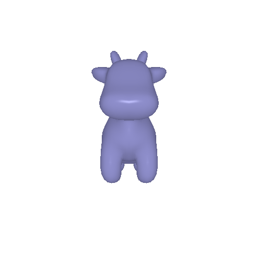

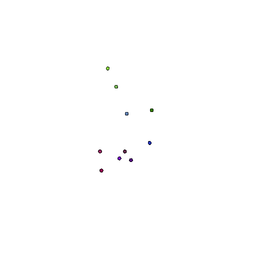

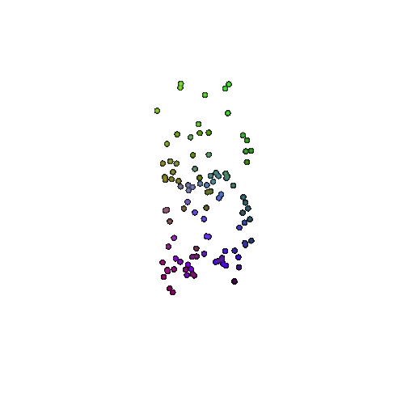

PointCloud w/ 1000 points

PointCloud w/ 10000 points

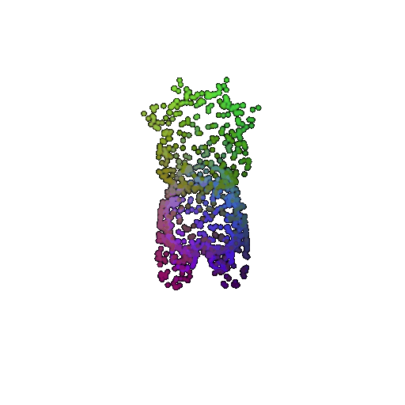

[figure not shown]